# s02 — indels + iterative mapping (chr19)

gwct

10/28/2026 11:44 EDT

```r
knitr::opts_chunk$set(echo = TRUE, warning = FALSE, message = FALSE, fig.align = "center")
library(ggplot2); library(dplyr); library(tidyr); library(readr)
source("analyses/lib/design.r")   # bartheme(), corecol(); knit from the project root
```

**Provenance**

- **Rendered from commit** `ff9caa48f3d6` (branch `mason2-sims`) on 2026-10-28 11:44
- **This notebook:** notebook as committed
- **Analysis code:** no uncommitted edits under `analyses/`
- Each data file’s producing script and command: the section’s `MANIFEST.yaml`

# 1 Question & design

**Does iterative (pseudo-it) mapping recover reference-biased *indels*, and how does that depend on the variant caller?** s02 extends s01 (SNP-only) by adding indels. Indels are the hard case for reference bias: a read spanning an unrepresented indel maps terribly, so the caller never sees it. They also make the consensus a different *length* than the reference, so iteration ≥2 lives in shifted coordinates and calls/reads must be lifted back to reference coordinates before scoring — the machinery v2/mason was built for.

**Scope caveat:** this is a **single seed (42)** first pass — no error bars yet. The seed-to-seed variance in s01 was <0.1 pt, so the point estimates should be representative; replicate seeds (43, 44) are a one-line config change + rerun.

Produced by `analyses/s02-indels/workflow.smk` (recovery) and `read_classification.smk`, config `config/config.yaml`, launched with the `run_*.sh` orchestrators.

```r
res <- "analyses/s02-indels/results/"
# --- truth check (Methods): stop rather than score recall against SNPs the reads do not carry ---
tc <- read_csv(paste0(res, "effective-truth/phantom-by-divergence.csv"), col_types = cols())
stopifnot(sum(tc$n_phantom_div + tc$n_phantom_het) == 0)
lv  <- c("gatk", "bcftools", "freebayes")

rec <- read_csv(paste0(res, "s02-indels-recovery-summary.csv")) %>%
  filter(divergence > 0) %>%
  mutate(caller = factor(caller, levels = lv), iteration = factor(iteration),
         snp_recall   = div_tp / n_truth_div,
         indel_recall = ifelse(n_truth_indel_div > 0, indel_div_tp / n_truth_indel_div, NA),
         snp_prec     = ifelse(n_called_snp   > 0, 1 - fp / n_called_snp, NA),
         indel_prec   = ifelse(n_called_indel > 0, 1 - fp_indel / n_called_indel, NA))

het <- read_csv(paste0(res, "s02-indels-het-summary.csv")) %>%
  mutate(caller = factor(caller, levels = lv), iteration = factor(iteration),
         het_recall = ifelse(n_truth_het > 0, het_tp / n_truth_het, NA))   # D=0 KEPT: germline baseline

rc <- read_csv(paste0(res, "s02-indels-readclass-by-iter.csv")) %>%
  mutate(caller = factor(caller, levels = lv), iteration = factor(iteration))   # D=0 KEPT: baseline

# s01 (SNP-only) SNP recall, for the "indels degrade SNP recovery" comparison
s01 <- read_csv("analyses/s01-baseline-iterative/results/s01-base-iterative-summary.csv") %>%
  filter(divergence > 0) %>%
  mutate(caller = factor(caller, levels = lv), iteration = factor(iteration),
         snp_recall_s01 = div_tp / n_truth_div)

n_iter <- max(as.integer(as.character(rec$iteration)))
cols   <- corecol(pal = "wilke", numcol = n_iter)
callcols <- corecol(pal = "wilke", numcol = 3)
```

# 2 Read classification

The mapping-side view. Each stacked bar is the composition of read placements at one iteration (exact / shifted / soft-clipped / mismapped / unmapped), per caller (rows) and divergence (columns). Iteration ≥2 BAMs are point-lifted from consensus to reference coordinates before classifying. `span_off` = correct start, but the read’s reference footprint is >10 bp off its true one (it was laid across the wrong indel structure); ≤0.014% of reads.

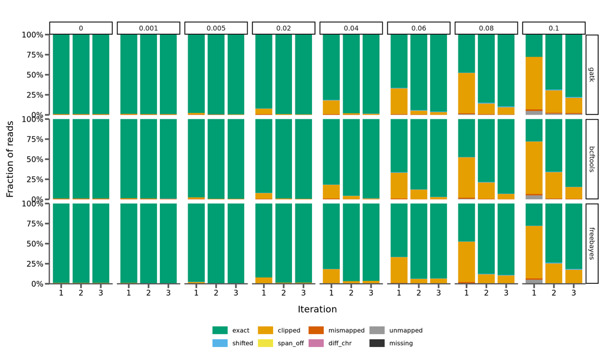

```r
classes <- c("exact", "shifted", "clipped", "span_off", "mismapped", "diff_chr", "unmapped", "missing")
class_cols <- c(exact = "#009E73", shifted = "#56B4E9", clipped = "#E69F00", span_off = "#F0E442",
                mismapped = "#D55E00", diff_chr = "#CC79A7", unmapped = "#999999", missing = "#333333")
comp <- rc %>% group_by(caller, divergence, iteration) %>%
  summarize(across(all_of(paste0(classes, "_prop")), mean), .groups = "drop") %>%
  pivot_longer(-c(caller, divergence, iteration), names_to = "class", values_to = "prop") %>%
  mutate(class = factor(sub("_prop", "", class), levels = classes))
ggplot(comp, aes(x = iteration, y = prop, fill = class)) +
  geom_col(width = 0.85) +
  facet_grid(caller ~ divergence) +
  scale_y_continuous(labels = scales::percent, expand = c(0, 0)) +
  scale_fill_manual(values = class_cols) +
  xlab("Iteration") + ylab("Fraction of reads") +
  bartheme() + theme(legend.position = "bottom", legend.text = element_text(size = 8),
                     legend.title = element_blank(), legend.key.size = unit(0.4, "cm"))
```

**Interpretation.** Single-shot mapping with indels is **brutal** — at D=0.10 only ~28% of reads map exactly and ~65% are soft-clipped (vs ~40% clipped SNP-only in s01: the indels add a lot of clipping). iter1 is identical across the three caller rows (everyone maps to the reference — the control). Iteration then recovers the mapping dramatically (clipped → ~15–19%, exact → ~78–84% by iter3), because once indels are baked into the consensus, reads span them cleanly. `shifted` stays ≤ 1.2%; tables before 2026-10-27 showed up to ~22% shifted at iter3, almost all of it the truth BAM’s alignment-start error (see Methods). **`missing` is ~0 everywhere** — the point-lift retains every read, even the indel-spanning ones, across the whole sweep. This falling clip rate is the mechanism behind the variant recovery below.

# 3 Variant recovery — SNPs vs indels

## 3.1 Recovery by iteration

Recall (recovered / truth) by caller; at each divergence the grey connector spans the iterations, so its length is the iteration gain.

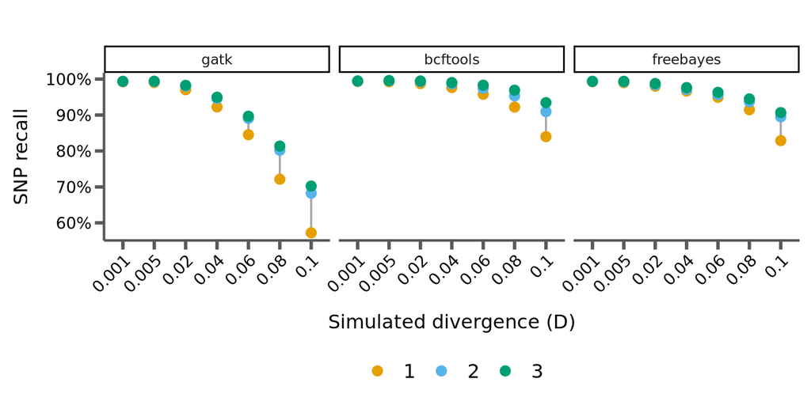

```r
agg <- rec %>% group_by(caller, divergence, iteration) %>%
  summarize(snp = mean(snp_recall), indel = mean(indel_recall), .groups = "drop")
ggplot(agg, aes(x = factor(divergence), y = snp, color = iteration)) +
  geom_line(aes(group = divergence), color = "grey65", size = 0.6) +
  geom_point(size = 2.6) + facet_wrap(~caller) +
  scale_x_discrete(guide = guide_axis(angle = 45)) +
  scale_y_continuous(labels = scales::percent) +
  scale_color_manual(values = cols, name = "Iteration") +
  xlab("Simulated divergence (D)") + ylab("SNP recall") +
  bartheme() + theme(legend.position = "bottom")
```

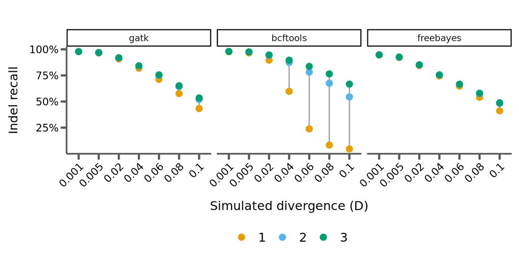

```r
ggplot(agg, aes(x = factor(divergence), y = indel, color = iteration)) +
  geom_line(aes(group = divergence), color = "grey65", size = 0.6) +
  geom_point(size = 2.6) + facet_wrap(~caller) +
  scale_x_discrete(guide = guide_axis(angle = 45)) +
  scale_y_continuous(labels = scales::percent) +
  scale_color_manual(values = cols, name = "Iteration") +
  xlab("Simulated divergence (D)") + ylab("Indel recall") +
  bartheme() + theme(legend.position = "bottom")
```

**Interpretation.** For **SNPs**, iteration helps most for **gatk** (its assembler collapses at high divergence) — the s01 story, now with indels also present. For **indels**, the picture inverts: **bcftools** starts almost unable to call indels at high divergence (single-shot indel recall ≈ 5% at D=0.10) and iteration rescues it enormously (→ ~67%). gatk and freebayes recover indels far better at single-shot (~41–43%) and gain less. Iteration rescues whichever caller is weak — a *different* caller for each variant type.

## 3.2 The caller flip

Single-shot (iteration 1) SNP vs indel recall, side by side, at D=0.10 — the clearest view of the flip.

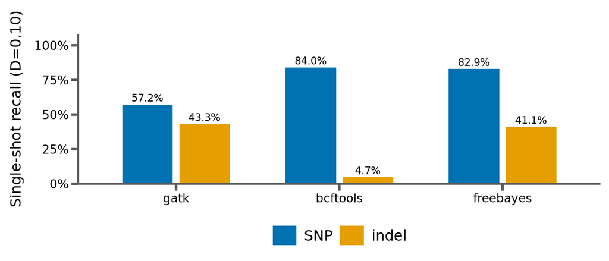

```r
flip <- rec %>% filter(iteration == "1", divergence == 0.10) %>%
  select(caller, SNP = snp_recall, indel = indel_recall) %>%
  pivot_longer(c(SNP, indel), names_to = "variant", values_to = "recall") %>%
  mutate(variant = factor(variant, levels = c("SNP", "indel")))
ggplot(flip, aes(x = caller, y = recall, fill = variant)) +
  geom_col(position = position_dodge(0.7), width = 0.62) +
  geom_text(aes(label = scales::percent(recall, accuracy = 0.1)),
            position = position_dodge(0.7), vjust = -0.4, size = 3) +
  scale_y_continuous(labels = scales::percent, limits = c(0, 1), expand = expansion(c(0, 0.08))) +
  scale_fill_manual(values = c(SNP = "#0072b2", indel = "#e69f00"), name = NULL) +
  xlab(NULL) + ylab("Single-shot recall (D=0.10)") +
  bartheme() + theme(legend.position = "bottom")
```

## 3.3 Recovered counts & recall table

```r
library(kableExtra)
tab <- rec %>%
  mutate(cell_snp   = sprintf("%.1f%%", 100 * snp_recall),
         cell_indel = sprintf("%.1f%%", 100 * indel_recall)) %>%
  select(caller, divergence, iteration, cell_snp, cell_indel) %>%
  pivot_wider(names_from = iteration, values_from = c(cell_snp, cell_indel)) %>%
  arrange(caller, divergence)
grp  <- tab %>% count(caller)
disp <- tab %>% select(-caller)
kbl <- knitr::kable(disp, align = "r",
    col.names = c("divergence", paste0("SNP i", 1:n_iter), paste0("indel i", 1:n_iter)),
    caption = "Recall by iteration: SNP (left) and indel (right), seed 42.") %>%
  kable_styling(bootstrap_options = c("striped", "hover", "condensed"),
                full_width = FALSE, position = "center")
start <- 1
for (i in seq_len(nrow(grp))) { kbl <- kbl %>% pack_rows(as.character(grp$caller[i]), start, start + grp$n[i] - 1); start <- start + grp$n[i] }
kbl
```

Recall by iteration: SNP (left) and indel (right), seed 42.

| divergence | SNP i1 | SNP i2 | SNP i3 | indel i1 | indel i2 | indel i3 |
| --- | --- | --- | --- | --- | --- | --- |
| **gatk** |  |  |  |  |  |  |
| 0.001 | 99.2% | 99.4% | 99.4% | 97.7% | 97.8% | 97.8% |
| 0.005 | 99.0% | 99.3% | 99.4% | 96.5% | 96.8% | 96.9% |
| 0.020 | 97.0% | 98.1% | 98.3% | 90.8% | 91.8% | 92.0% |
| 0.040 | 92.3% | 94.6% | 95.0% | 81.9% | 83.9% | 84.2% |
| 0.060 | 84.5% | 89.1% | 89.7% | 71.3% | 75.1% | 75.5% |
| 0.080 | 72.1% | 80.2% | 81.4% | 57.6% | 64.2% | 65.1% |
| 0.100 | 57.2% | 68.2% | 70.2% | 43.3% | 51.9% | 53.4% |
| **bcftools** |  |  |  |  |  |  |
| 0.001 | 99.3% | 99.5% | 99.5% | 97.7% | 97.9% | 97.9% |
| 0.005 | 99.2% | 99.5% | 99.6% | 96.6% | 97.4% | 97.5% |
| 0.020 | 98.8% | 99.3% | 99.5% | 89.6% | 94.2% | 94.6% |
| 0.040 | 97.6% | 98.7% | 99.0% | 59.7% | 87.4% | 89.6% |
| 0.060 | 95.8% | 97.4% | 98.3% | 23.8% | 78.2% | 83.6% |
| 0.080 | 92.2% | 95.3% | 96.9% | 8.3% | 67.6% | 76.5% |
| 0.100 | 84.0% | 90.9% | 93.4% | 4.7% | 54.4% | 66.7% |
| **freebayes** |  |  |  |  |  |  |
| 0.001 | 99.3% | 99.4% | 99.4% | 94.6% | 94.7% | 94.7% |
| 0.005 | 99.0% | 99.2% | 99.4% | 92.1% | 92.5% | 92.6% |
| 0.020 | 98.0% | 98.4% | 98.8% | 84.4% | 85.0% | 85.2% |
| 0.040 | 96.7% | 97.1% | 97.6% | 74.5% | 75.4% | 75.5% |
| 0.060 | 94.9% | 95.7% | 96.3% | 64.8% | 66.4% | 66.6% |
| 0.080 | 91.5% | 93.7% | 94.5% | 54.0% | 57.6% | 58.0% |
| 0.100 | 82.9% | 89.5% | 90.7% | 41.1% | 48.1% | 48.8% |

## 3.4 Precision

Precision of the recovered set (1 − FP/called), SNP and indel, by caller.

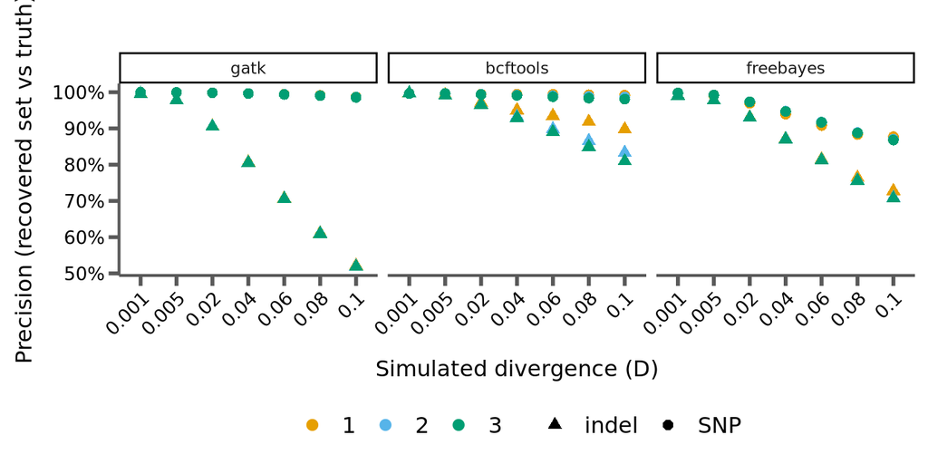

```r
prc <- rec %>% select(caller, divergence, iteration, SNP = snp_prec, indel = indel_prec) %>%
  pivot_longer(c(SNP, indel), names_to = "variant", values_to = "prec")
ggplot(prc, aes(x = factor(divergence), y = prec, color = iteration, shape = variant)) +
  geom_point(size = 2.4) + facet_wrap(~caller) +
  scale_x_discrete(guide = guide_axis(angle = 45)) +
  scale_y_continuous(labels = scales::percent) +
  scale_color_manual(values = cols, name = "Iteration") +
  scale_shape_manual(values = c(SNP = 16, indel = 17), name = NULL) +
  xlab("Simulated divergence (D)") + ylab("Precision (recovered set vs truth)") +
  bartheme() + theme(legend.position = "bottom")
```

## 3.5 Indels degrade SNP recovery

Comparing single-shot (iter1) SNP recall **with indels (s02)** vs **SNP-only (s01)** — the indels the sample also carries make nearby SNPs harder to recover.

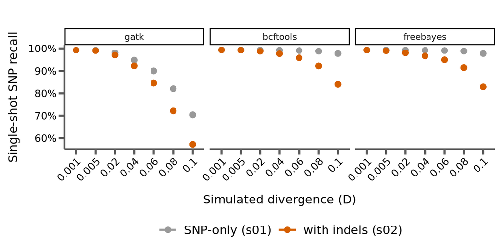

```r
cmp <- rec %>% filter(iteration == "1") %>% select(caller, divergence, s02 = snp_recall) %>%
  left_join(s01 %>% filter(iteration == "1") %>% select(caller, divergence, s01 = snp_recall_s01),
            by = c("caller", "divergence")) %>%
  pivot_longer(c(s01, s02), names_to = "sim", values_to = "snp_recall") %>%
  mutate(sim = recode(sim, s01 = "SNP-only (s01)", s02 = "with indels (s02)"))
ggplot(cmp, aes(x = factor(divergence), y = snp_recall, color = sim)) +
  geom_line(size = 1) + geom_point(size = 2.4) + facet_wrap(~caller) +
  scale_x_discrete(guide = guide_axis(angle = 45)) +
  scale_y_continuous(labels = scales::percent) +
  scale_color_manual(values = c("SNP-only (s01)" = "#999999", "with indels (s02)" = "#d55e00"), name = NULL) +
  xlab("Simulated divergence (D)") + ylab("Single-shot SNP recall") +
  bartheme() + theme(legend.position = "bottom")
```

**Interpretation.** Adding indels lowers single-shot SNP recall for every caller (the reads around an indel are clipped/mismapped, taking nearby SNPs down with them) — largest at high divergence. So ignoring indels *understates* SNP reference bias, and iteration recovers this indel-induced SNP loss too.

# 4 Per-variant read fate: SNPs in the presence of indels

The recall numbers say indels lower SNP recovery; this section shows — per SNP, directly at the reference base — *how*, and compares it to the SNP-only s01 baseline. It is the project’s standard read-fate analysis (`analyses/lib/variant_read_fate.py --aggregate`, `run_vrf_aggregate.sh`, whole chromosome, all callers × divergences), with **one s02-specific addition**: at iteration > 1 the consensus is length-shifted by recovered indels, so reads are in *consensus* coordinates — the tool lifts each SNP position and each read’s true start into consensus coordinates via that iteration’s `ref2cons.chain` before classifying at `p`. All definitions (covering reads by true span from the `oP` tag; `n_true_alt` via the `oH` haplotype tag; `f_alt` = alt aligned at `p` / reads truly carrying alt; the per-`p` classes) are exactly as in the s01 section. **The SNP set is s02’s hom-div SNPs — we are tracing SNP fate in the indel context, not the fate of the indels themselves.**

```r
library(ggalluvial); library(patchwork)
AGG2 <- "analyses/s02-indels/results/vrf-agg"                     # s02 aggregate tables
AGG1 <- "analyses/s01-baseline-iterative/results/vrf-agg"          # s01 baseline, for comparison
lvc  <- c("gatk", "bcftools", "freebayes")
rdcsv <- function(dir, pat) bind_rows(lapply(list.files(dir, pat, full.names = TRUE), read_csv, col_types = cols()))
h2 <- rdcsv(AGG2, "hcomp.csv$") %>% mutate(caller = factor(caller, levels = lvc), section = "s02 (indels)")
h1 <- rdcsv(AGG1, "hcomp.csv$") %>% mutate(caller = factor(caller, levels = lvc), section = "s01 (SNP-only)")
gtraj2 <- rdcsv(AGG2, "gtraj.csv$")
```

## 4.1 Do indels degrade SNP mapping? (s01 vs s02)

Left: fraction of *called* SNPs’ reads that are clipped over `p` — the direct indel effect. Right: `alt maps at p` for *not-called* SNPs — how much the base is still there. Dashed = s01, solid = s02.

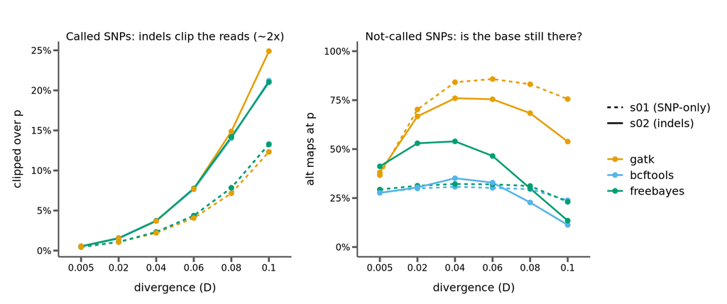

```r
cmp <- bind_rows(h1, h2) %>% filter(iteration == 1) %>%
  mutate(clip_frac = clipped / n_reads, alt_frac = alt_at_p / n_reads)
lt <- c(`s01 (SNP-only)` = "22", `s02 (indels)` = "solid")
p_clip <- cmp %>% filter(status == "called") %>%
  ggplot(aes(factor(divergence), clip_frac, color = caller, linetype = section, group = interaction(caller, section))) +
  geom_line(linewidth = 0.9) + geom_point(size = 2.2) + scale_y_continuous(labels = scales::percent) +
  scale_color_manual(values = corecol(pal = "wilke", numcol = 3), name = "caller") +
  scale_linetype_manual(values = lt, name = NULL) +
  labs(x = "divergence (D)", y = "clipped over p", title = "Called SNPs: indels clip the reads (~2x)") + bartheme()
p_alt <- cmp %>% filter(status == "not_called") %>%
  ggplot(aes(factor(divergence), alt_frac, color = caller, linetype = section, group = interaction(caller, section))) +
  geom_line(linewidth = 0.9) + geom_point(size = 2.2) + scale_y_continuous(labels = scales::percent, limits = c(0, 1)) +
  scale_color_manual(values = corecol(pal = "wilke", numcol = 3), name = "caller") +
  scale_linetype_manual(values = lt, name = NULL) +
  labs(x = "divergence (D)", y = "alt maps at p", title = "Not-called SNPs: is the base still there?") + bartheme()
patchwork::wrap_plots(p_clip, p_alt, ncol = 2, guides = "collect")
```

**Interpretation.** Left: indels roughly **double** the clipping of called-SNP reads (e.g. at D=0.10, <sub>13%→</sub>21–25%) — reads spanning a nearby unrepresented indel get soft-clipped, taking the SNP with them. Right: at high divergence, indels **lower** not-called `alt_at_p` for every caller (gatk 76%→54%, bcftools 24%→11%, freebayes 23%→13% at D=0.10) — so indels add an **alignment-limited** component on top of s01’s assembler ceiling. **Caveat:** the *not-called set differs* between s01 and s02, so this mixes “same SNP, worse mapping” with “different SNPs uncalled.” That’s why freebayes’ not-called `alt_at_p` is *higher* in s02 at low divergence: near an indel, freebayes tends to emit a complex/multiallelic call instead of the simple SNP (§ VCF inflation), so the base is present but the SNP-as-such isn’t called.

## 4.2 Why SNPs stay uncalled (s02)

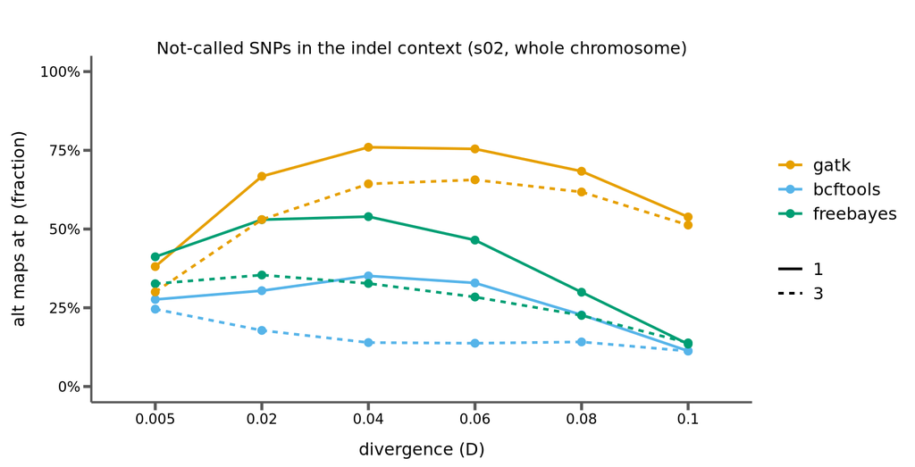

```r
h2 %>% filter(status == "not_called", iteration %in% c(1, 3)) %>% mutate(alt_frac = alt_at_p / n_reads) %>%
  ggplot(aes(factor(divergence), alt_frac, color = caller, linetype = factor(iteration),
             group = interaction(caller, iteration))) +
  geom_line(linewidth = 0.9) + geom_point(size = 2.3) +
  scale_y_continuous(labels = scales::percent, limits = c(0, 1)) +
  scale_color_manual(values = corecol(pal = "wilke", numcol = 3), name = "caller") +
  scale_linetype_manual(values = c(`1` = "solid", `3` = "22"), name = "iteration") +
  labs(x = "divergence (D)", y = "alt maps at p (fraction)", title = "Not-called SNPs in the indel context (s02, whole chromosome)") +
  bartheme()
```

## 4.3 What maps at position p (s02)

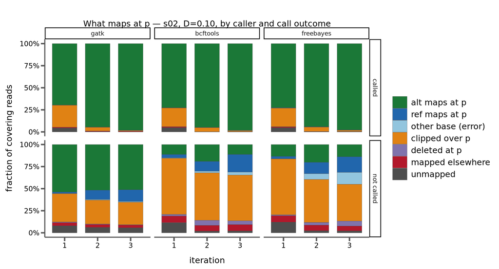

```r
cats <- c("alt_at_p", "ref_at_p", "err_at_p", "clipped", "deleted", "mapped_elsewhere", "unmapped")
nice <- c(alt_at_p = "alt maps at p", ref_at_p = "ref maps at p", err_at_p = "other base (error)",
          clipped = "clipped over p", deleted = "deleted at p", mapped_elsewhere = "mapped elsewhere", unmapped = "unmapped")
fcol <- setNames(c("#1b7837", "#2166ac", "#92c5de", "#e08214", "#8073ac", "#b2182b", "#4d4d4d"), unname(nice[cats]))
h2 %>% filter(divergence == 0.10) %>%
  pivot_longer(all_of(cats), names_to = "atp", values_to = "reads") %>%
  mutate(frac = reads / n_reads, atp = factor(nice[atp], levels = unname(nice[cats])),
         status = recode(status, called = "called", not_called = "not called")) %>%
  ggplot(aes(factor(iteration), frac, fill = atp)) + geom_col(width = 0.75, color = "grey30", linewidth = 0.12) +
  facet_grid(status ~ caller) + scale_fill_manual(values = fcol, name = "what is at position p") +
  scale_y_continuous(labels = scales::percent) +
  labs(x = "iteration", y = "fraction of covering reads", title = "What maps at p — s02, D=0.10, by caller and call outcome") +
  bartheme()
```

## 4.4 Joint state across iterations (s02, G)

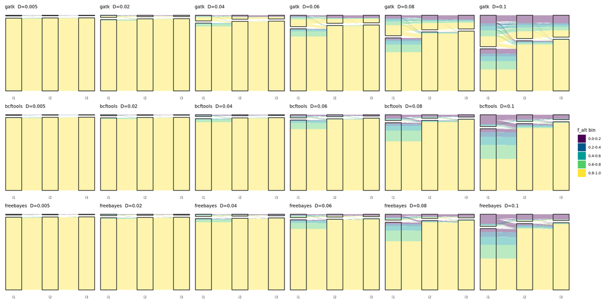

```r
BIN   <- c("0.0-0.2", "0.2-0.4", "0.4-0.6", "0.6-0.8", "0.8-1.0")
fbcol <- setNames(hcl.colors(5, "Viridis"), BIN)
Glev  <- c(paste("not called", BIN, sep = " · "), "gap", paste("called", BIN, sep = " · "))
makeG <- function(cc, dd) {
  g <- gtraj2 %>% filter(caller == cc, divergence == dd, fb1 %in% BIN, fb2 %in% BIN, fb3 %in% BIN)
  lodes <- g %>% mutate(id = row_number()) %>%
    pivot_longer(c(s1, fb1, s2, fb2, s3, fb3), names_to = c(".value", "iter"), names_pattern = "([a-z]+)([0-9])") %>%
    transmute(id, n = n_snps, iter, status = ifelse(s == "not_called", "not called", "called"),
              fb = factor(fb, levels = BIN), state = factor(paste(status, fb, sep = " · "), levels = Glev), is_gap = FALSE)
  gapN <- round(0.03 * sum(g$n_snps))
  lodes <- bind_rows(lodes, tibble(id = max(lodes$id) + 1, n = gapN, iter = c("1", "2", "3"), status = "gap",
                     fb = factor(NA, levels = BIN), state = factor("gap", levels = Glev), is_gap = TRUE))
  box <- lodes %>% filter(!is_gap) %>% group_by(iter, status) %>% summarize(n = sum(n), .groups = "drop") %>%
    group_by(iter) %>% mutate(ncall = sum(n[status == "called"])) %>% ungroup() %>%
    mutate(pos = as.integer(iter), xmin = pos - 0.22, xmax = pos + 0.22,
           ymin = ifelse(status == "called", 0, ncall + gapN), ymax = ifelse(status == "called", ncall, ncall + gapN + n))
  ggplot(lodes, aes(x = iter, stratum = state, alluvium = id, y = n, fill = fb, alpha = is_gap)) +
    geom_flow() +
    geom_rect(data = box, aes(xmin = xmin, xmax = xmax, ymin = ymin, ymax = ymax), inherit.aes = FALSE, fill = "white") +
    geom_stratum(color = NA, width = 0.44) +
    geom_rect(data = box, aes(xmin = xmin, xmax = xmax, ymin = ymin, ymax = ymax), inherit.aes = FALSE, fill = NA, color = "grey15", linewidth = 0.6) +
    scale_alpha_manual(values = c(`FALSE` = 0.4, `TRUE` = 0), guide = "none") +
    scale_fill_manual(values = fbcol, name = "f_alt bin", na.value = "white", na.translate = FALSE) +
    scale_x_discrete(labels = c("i1", "i2", "i3"), expand = c(0.08, 0.08)) +
    labs(x = NULL, y = NULL, title = sprintf("%s  D=%s", cc, format(dd))) +
    theme_minimal(base_size = 9) + theme(panel.grid = element_blank(), axis.text.y = element_blank(), plot.title = element_text(size = 9))
}
conds <- expand.grid(dd = c(0.005, 0.02, 0.04, 0.06, 0.08, 0.10), cc = lvc, stringsAsFactors = FALSE)
patchwork::wrap_plots(Map(makeG, conds$cc, conds$dd), ncol = 6, guides = "collect")
```

Within each panel the lower box is `called`, the upper `not called`; colour = `f_alt` bin. **Data dictionary** for `results/vrf-agg/vrf-agg-<caller>-<div>-{gtraj,hcomp}.csv` is identical to the s01 section (hcomp = per-`p` read-fate counts summed over SNPs per iteration × call-status; gtraj = SNP counts per 3-iteration (status, `f_alt`-bin) trajectory).

## 4.5 Companion decomposition: what changes when a SNP flips to called?

Exactly the s01 companion decomposition, run on the s02 (indel-context) data: for each SNP we join the position-centric pileup at `p` (`--pileup`, chain-lifted to consensus coords for iter>1) with the mismapped-in/out counts and the **off-`p` neighborhood load** (unrecovered hom-div SNPs within ±200 bp), then compare across the three fates (flip / stayed-called / stayed-not-called). Shared code: `analyses/lib/decomp_figs.R` (+ `run_vrf_pileup.sh`, `run_neighborhood.sh`); definitions are as in the s01 section.

```r
source("analyses/lib/decomp_figs.R")
pairs <- decomp_load("analyses/s02-indels/results/vrf-pileup",
                     "analyses/s02-indels/results/neighborhood/neighborhood-per-snp.csv")
```

Per-SNP **distributions** by fate (boxplots), one figure per divergence:

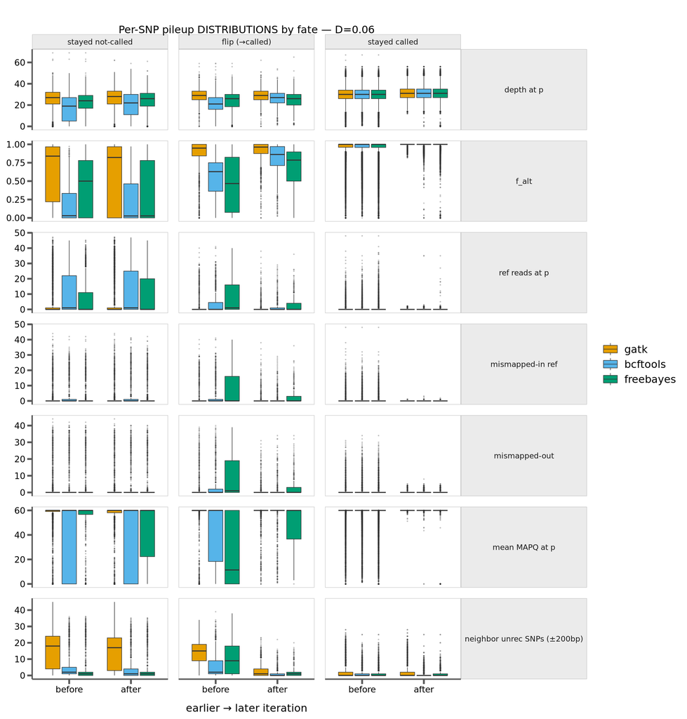

```r
decomp_distfig(pairs, 0.06)
```

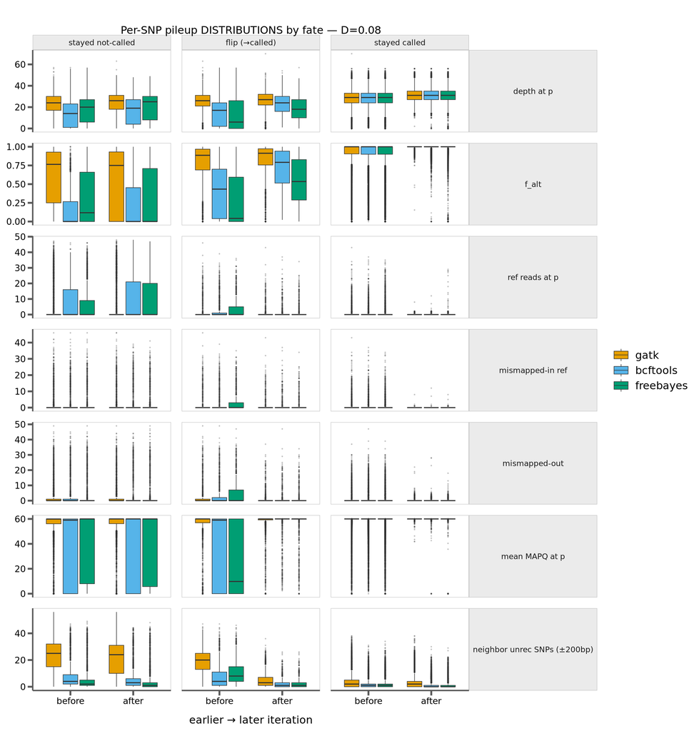

```r
decomp_distfig(pairs, 0.08)
```

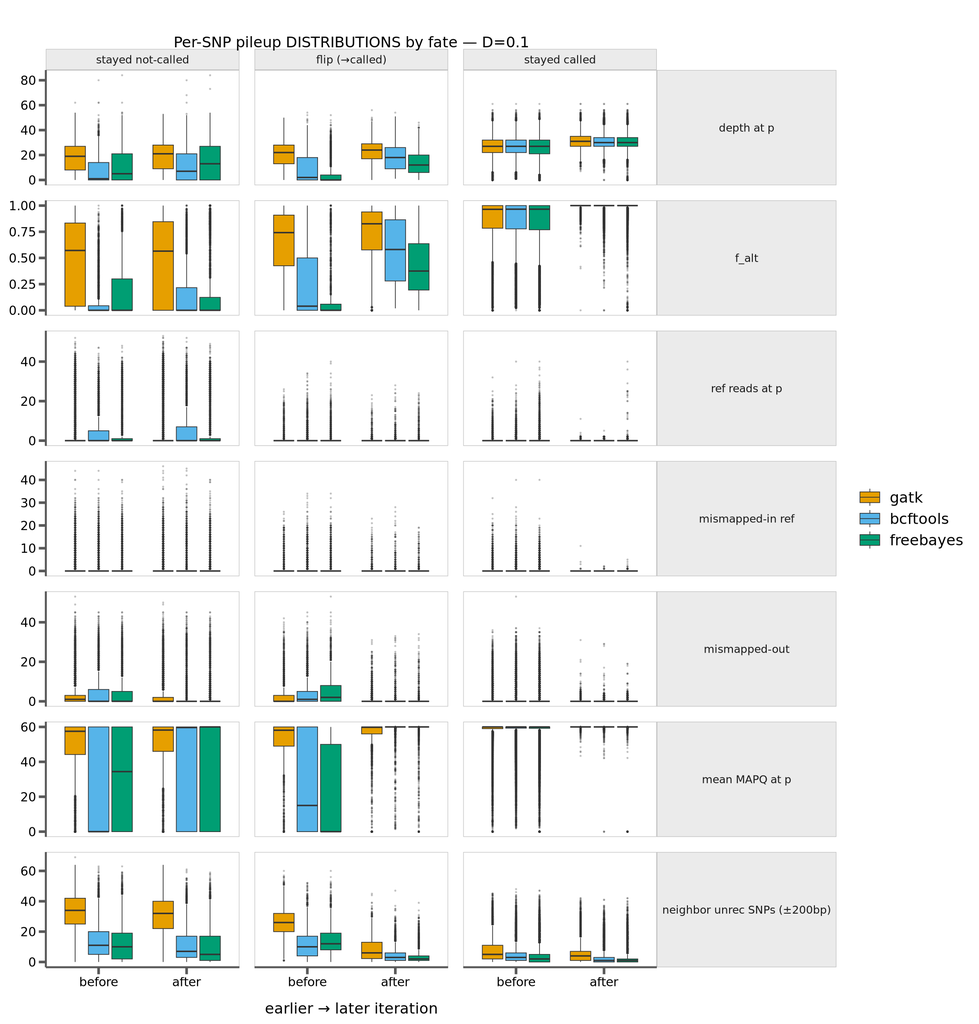

```r
decomp_distfig(pairs, 0.10)
```

**Mean** trend across divergences, one figure per fate:

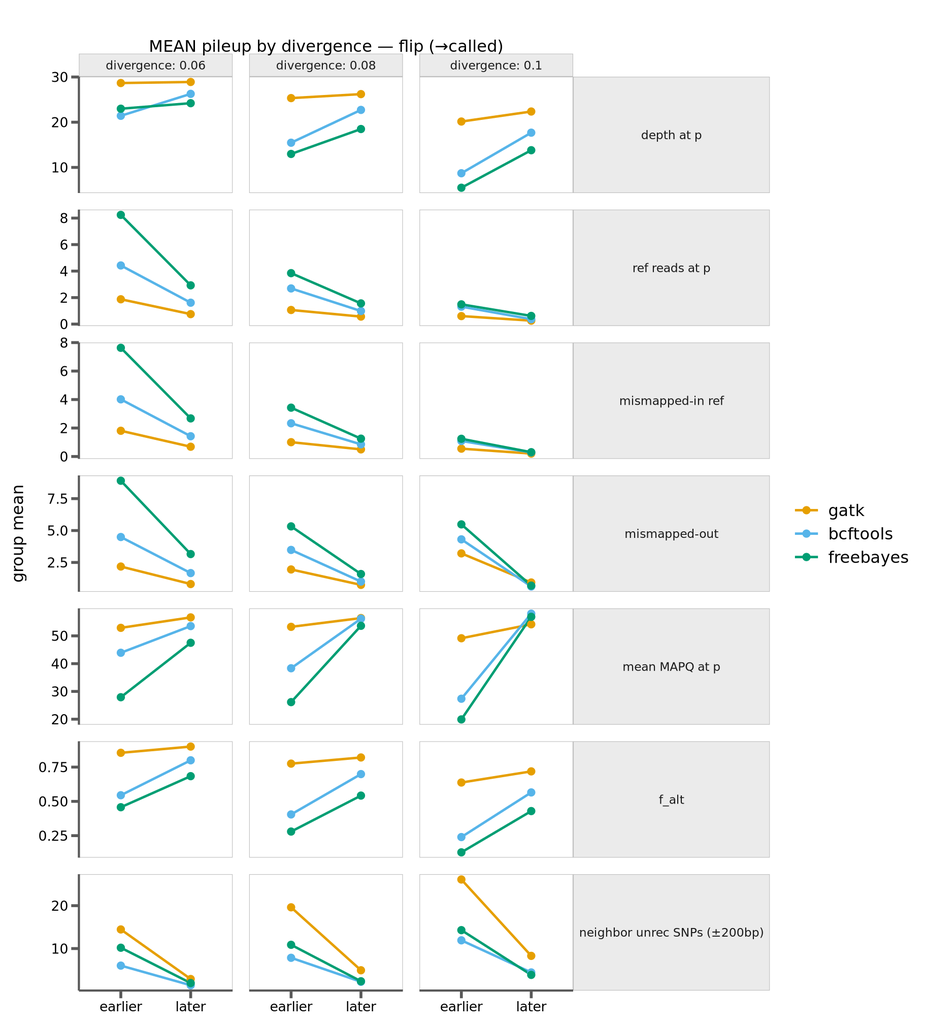

```r
decomp_meantrend(pairs, "flip (→called)")
```

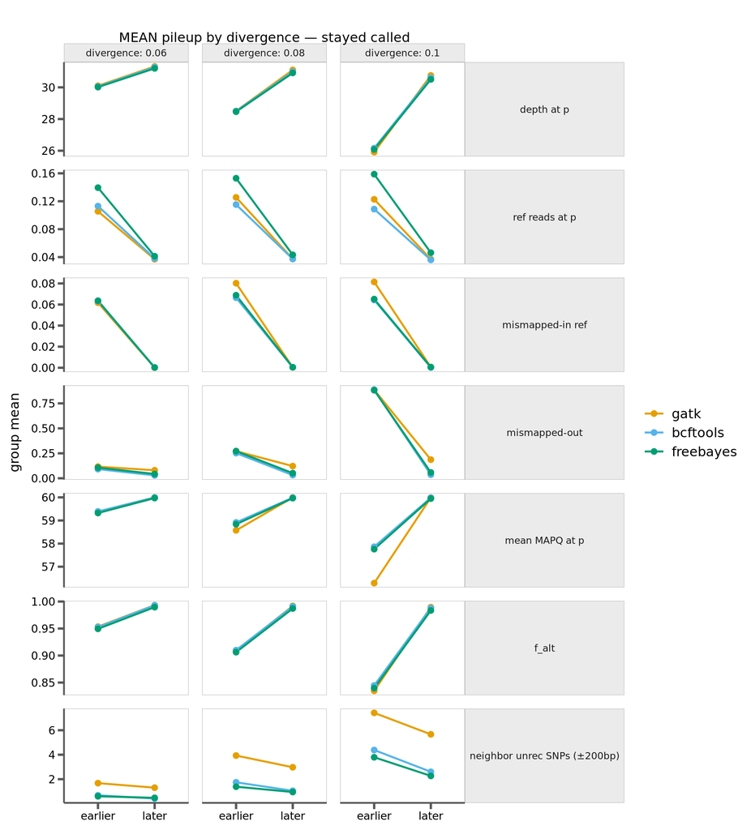

```r
decomp_meantrend(pairs, "stayed called")
```

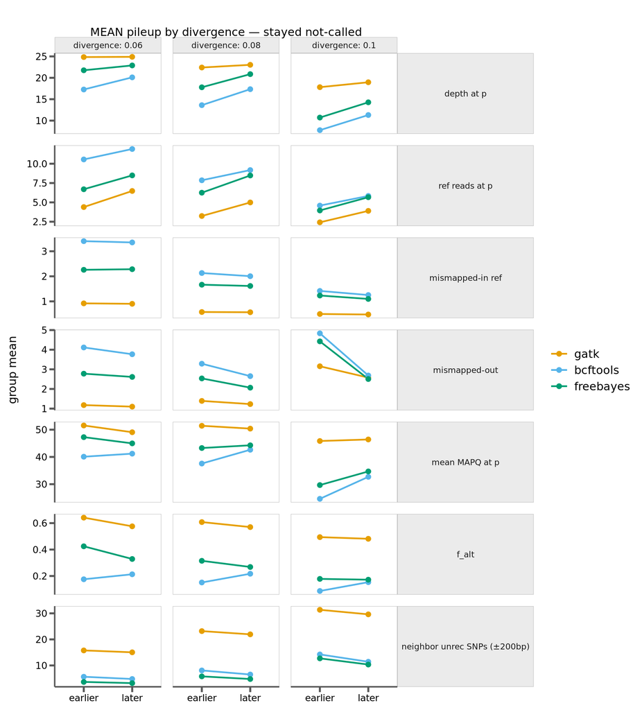

```r
decomp_meantrend(pairs, "stayed not-called")
```

The **gatk signature** — how often the pileup at `p` is already clean before the flip, and how little it moves:

```r
kable(decomp_gatksig_clean(pairs), table.attr = 'class="center"',
      caption = "Fraction of flip SNPs whose pileup at p already looked called-ready before the flip (D=0.10).")
```

Fraction of flip SNPs whose pileup at p already looked called-ready before the flip (D=0.10).

| caller | n flips | pileup already clean before flip |
| --- | --- | --- |
| gatk | 3870 | 41% |
| bcftools | 2766 | 5% |
| freebayes | 2276 | 4% |

```r
kable(decomp_gatksig_delta(pairs), table.attr = 'class="center"',
      caption = "Mean absolute change in each pileup axis across the flip (D=0.10).")
```

Mean absolute change in each pileup axis across the flip (D=0.10).

| caller | Δ depth | Δ ref | Δ mismap-in | Δ MAPQ | Δ f_alt |
| --- | --- | --- | --- | --- | --- |
| gatk | 2.7 | 0.4 | 0.4 | 5.4 | 0.09 |
| bcftools | 9.7 | 1.1 | 0.9 | 30.6 | 0.33 |
| freebayes | 9.1 | 1.4 | 1.0 | 37.1 | 0.30 |

The **assemblable neighborhood** (off `p`) and the flips by **starting `f_alt` bin**:

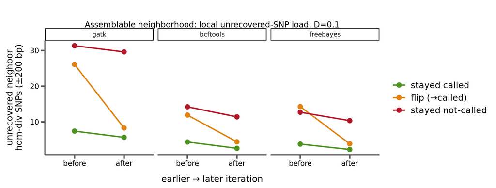

```r
decomp_neighfig("analyses/s02-indels/results/neighborhood/neighborhood-summary.csv")
```

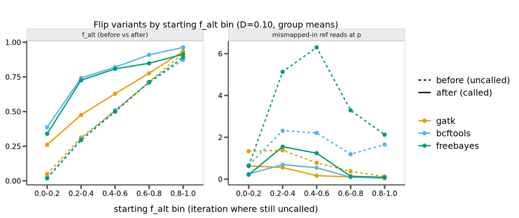

```r
decomp_bybin(pairs)
```

**Interpretation.** The mechanism is identical to s01 and unchanged by the indel context: **gatk** flips happen with the pileup at `p` already clean (largest “already clean” fraction, smallest per-axis change) — its neighborhood unrecovered-SNP load collapses (≈26→8 at D=0.10) as the consensus converges, making the region assemblable; **bcftools/freebayes** flips clear a contaminated pileup (mismapped-in ref reads leave, MAPQ rises). What indels *change* is the magnitude: the neighborhood load sits a little higher at each divergence (indels add local divergence the SNP-only count doesn’t even show).

# 5 Heterozygous site recovery

Het sites (`0/1`) are scored from the raw per-iteration caller VCF vs truth (het is never baked into the haploid consensus).

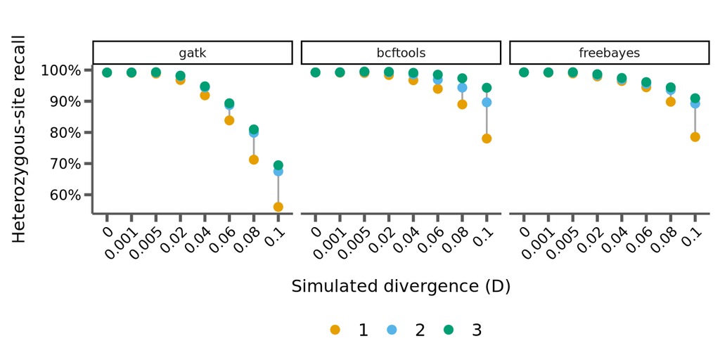

```r
hets <- het %>% group_by(caller, divergence, iteration) %>%
  summarize(m = mean(het_recall), .groups = "drop")
ggplot(hets, aes(x = factor(divergence), y = m, color = iteration)) +
  geom_line(aes(group = divergence), color = "grey65", size = 0.6) +
  geom_point(size = 2.6) + facet_wrap(~caller) +
  scale_x_discrete(guide = guide_axis(angle = 45)) +
  scale_y_continuous(labels = scales::percent) +
  scale_color_manual(values = cols, name = "Iteration") +
  xlab("Simulated divergence (D)") + ylab("Heterozygous-site recall") +
  bartheme() + theme(legend.position = "bottom")
```

**Interpretation.** Het recall tracks divergence recall per caller and improves with iteration for the same reason (falling effective divergence restores the alt-allele reads), mirroring s01.

# 6 Caller behavior: VCF inflation & multiallelic over-calling

The truth contains **no multiallelic sites** — every simulated variant is biallelic and at a disjoint position. Yet the callers, especially freebayes, emit many multiallelic and spanning-deletion (`*`) records. This is a pure calling artifact, and it’s why freebayes’ VCFs are large enough to have overrun Picard’s heap during liftover.

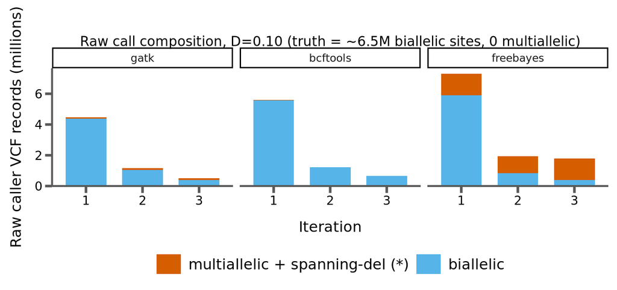

```r
comp2 <- read_csv(paste0(res, "s02-indels-callvcf-composition.csv")) %>%
  mutate(caller = factor(caller, levels = lv), iteration = factor(iteration),
         complex = star + multiallelic_extra, simple = total - (star + multiallelic_extra)) %>%
  select(caller, iteration, simple, complex) %>%
  pivot_longer(c(simple, complex), names_to = "kind", values_to = "n") %>%
  mutate(kind = factor(kind, levels = c("complex", "simple")))
ggplot(comp2, aes(x = iteration, y = n / 1e6, fill = kind)) +
  geom_col(width = 0.72) + facet_wrap(~caller) +
  scale_fill_manual(values = c(simple = "#56b4e9", complex = "#d55e00"),
                    labels = c(complex = "multiallelic + spanning-del (*)", simple = "biallelic"),
                    name = NULL) +
  scale_y_continuous(expand = expansion(c(0, 0.05))) +
  xlab("Iteration") + ylab("Raw caller VCF records (millions)") +
  ggtitle("Raw call composition, D=0.10 (truth = ~6.5M biallelic sites, 0 multiallelic)") +
  bartheme() + theme(legend.position = "bottom", plot.title = element_text(size = 11))
```

**Interpretation.** All three callers’ *total* counts fall with iteration (the real divergent SNPs get baked into the consensus, so fewer remain to call). But freebayes carries a large, **roughly constant floor of complex records** — ~1.4M multiallelic + spanning-deletion (`*`) records at *every* iteration, persisting even at iter3 where the mapping is clean. So it dominates once the real signal is stripped away: **~79% of freebayes’ iter3 calls are complex artifacts**, vs ~21% for gatk and <1% for bcftools. That the floor doesn’t fall with better mapping says the over-calling is **intrinsic to freebayes** — its haplotype windows generate competing overlapping candidates around het sites and error clusters — not merely a high-divergence mapping artifact. It does **not** affect the recovery numbers (we score the homozygous subset against biallelic truth), but it bloats the VCFs — it’s what overran Picard’s heap during liftover — and a light QUAL / min-alt-count filter would remove most of it.

# 7 Summary